# Laboratorio54-Parte2-MD

Leislie R. Manjarrez O.

2023-03-17

Hecho con gusto por Leislie R. Manjarrez O.

Laboratorio 54- Grafico de series financieras en R- Parte 2

El paquete quantmod permite obtener, transformar y dibujar datos financieros de diversas fuentes. En el siguiente ejemplo vamos a descargar los datos del SP500 desde Yahoo Finance y dibujarlos con la funcion chartSeries, que crea por defecto lo que se conoce como grafico de velas japonesas. Es posible transformar los datos diarios en velas semanales o mensuales con las funciones as.weekly y as.monthly

Instalamos la paqueteria correspondiente install.packages(“quantmod”)

Llamamos a la libreria correspondiente

```r
library(quantmod)
```

Creamos los objetos de fechas

```r
inicio <- "2020-10-01"
fin <- "2021-01-01"
```

Obtenemos los datos

```r
getSymbols("^GSPC",
           from = inicio, to = fin,
           src = "yahoo")
```

```
## [1] "^GSPC"
```

Dibujamos la serie

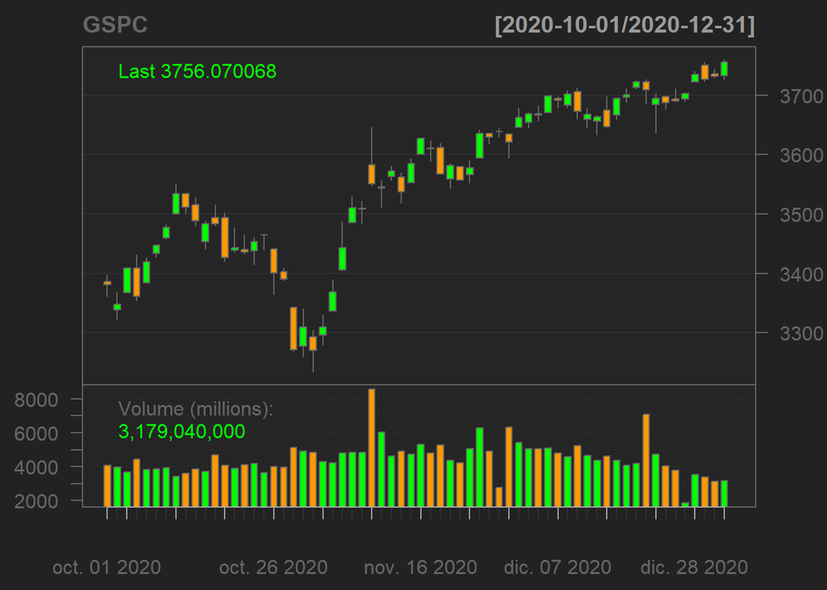

```r
chartSeries(GSPC)
```

Es posible cambiar el tema y los estilos. Para ver las opciones que existen ejecuta el siguiente comando

```r
?chartSeries
```

```
## starting httpd help server ... done
```

Para personalizar el grafo utilizamos el argumento theme; para alto-bajo-cierre bar.type; para vela alza up.col y para vela baja dn.col

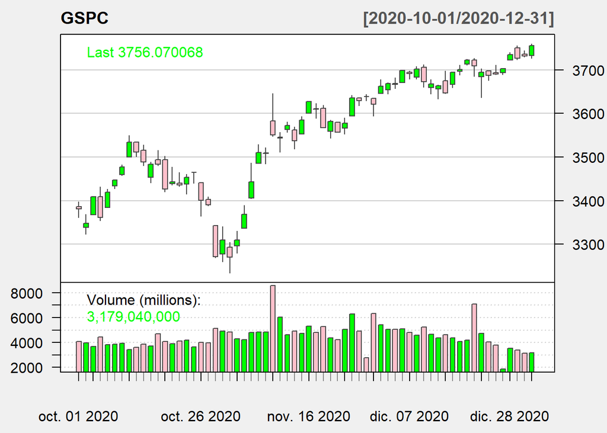

```r
chartSeries(GSPC,
theme = chartTheme("white"),
bar.type = "hlc",
up.col = "green",
dn.col = "pink")
```

Para agregar indicadores tecnicos al grafico, como bandas de Bollinger o medias moviles exponenciales, utilizamos las funciones que inician con add

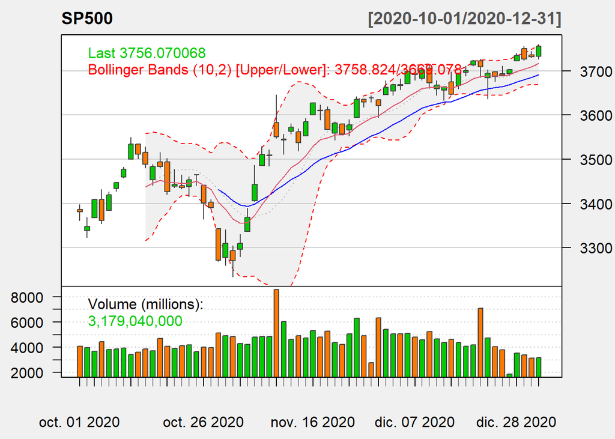

```r
chartSeries(GSPC,
            theme = chartTheme("white"),
            name = "SP500",
            TA = list("addBBands(n = 10)",
                      "addVo()",
                      "addEMA(20)",
                      "addEMA(10, col = 2)"))
```

La funcion chart_Series son algunas de las funciones experimentales existentes en la libreria quantmod

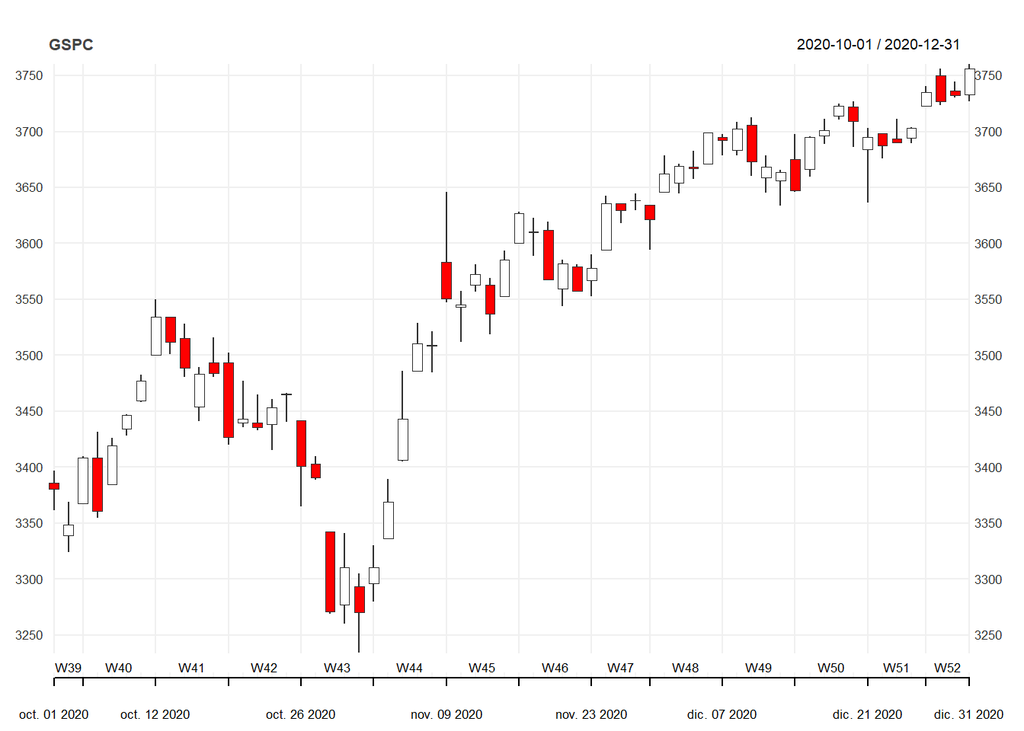

```r
chart_Series(GSPC)
```

El tema del grafico se puede personalizar con la lista de argumentos que proporciona chart_theme

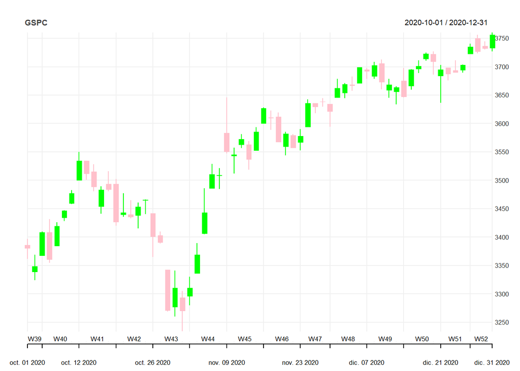

```r
myTheme <- chart_theme()
myTheme$col$dn.col <- "pink"
  myTheme$col$dn.border <- "pink"
    myTheme$col$up.col <- "green"
      myTheme$col$up.border <- "green"
        myTheme$rylab <- TRUE
        myTheme$lylab <- FALSE
        chart_Series(GSPC, theme = myTheme)
```

Es puedes agregar indicadores tecnicos de la misma manera que en la funcion de la seccion anterior

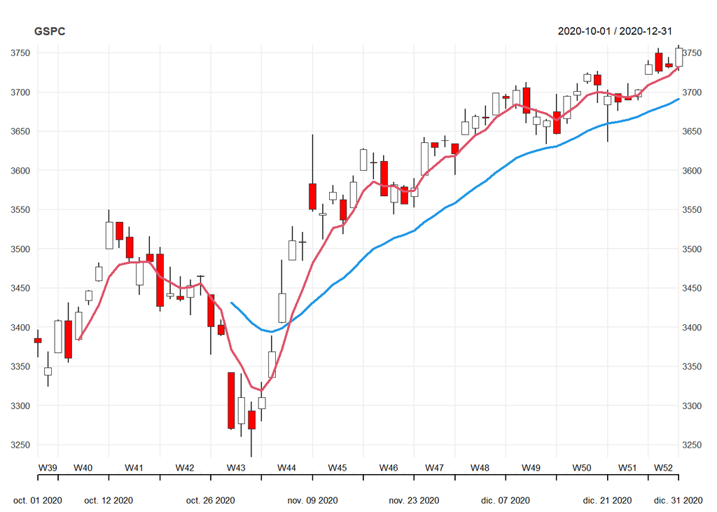

```r
chart_Series(GSPC, TA = list("add_EMA(n = 20, col = 4,
                                lwd = 2)",
                               "add_EMA(n = 5, col = 2,
                                lwd = 2)"))
```